# Alligator Harbor Aquatic Preserve

SEACAR Water Quality Analysis

Last compiled on 15 July, 2026

# Indicators

## Nutrients

### Total Nitrogen - Discrete

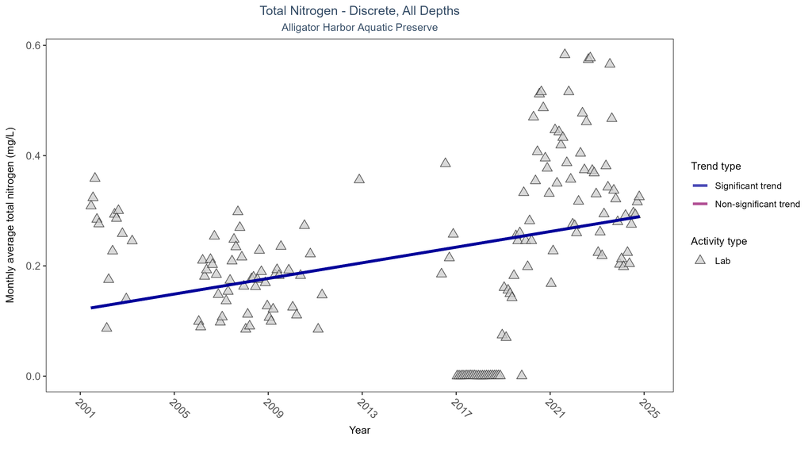

Scatter plot of monthly average total nitrogen over time. If the time series included ten or more years of discrete observations, a significant (blue) or non-significant (magenta) trend line is also shown. Only nitrogen values obtained from laboratory analyses (triangles) are included in the plot.

Table:

Monthly average total nitrogen increased by 0.01 mg/L per year.

| Activity Type | Statistical Trend | Sample Count | Years with Data | Period of Record | Median Result Value | Tau | Sen Intercept | Sen Slope | P |
| --- | --- | --- | --- | --- | --- | --- | --- | --- | --- |
| Lab | Increasing trend | 1625 | 19 | 2001 - 2024 | 0.2 | 0.27903 | 0.12051 | 0.00709 | 0 |

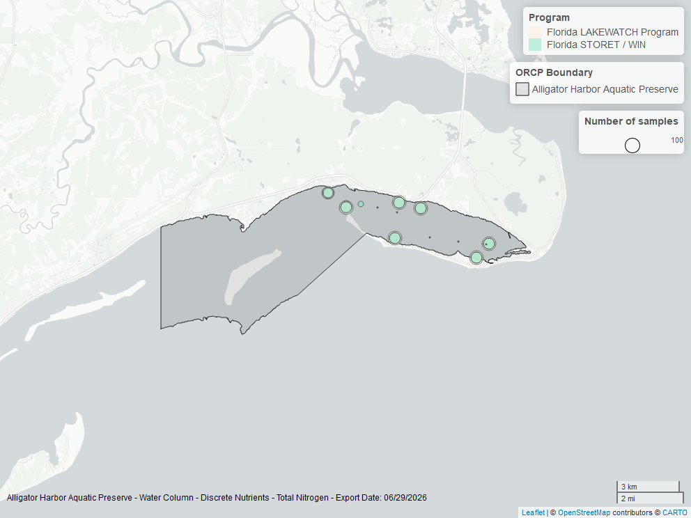

Map showing location of discrete water quality sampling locations within the boundaries of *Alligator Harbor Aquatic Preserve*. The bubble size on the maps above reflect the amount of data available at each sampling site.

### Total Phosphorus - Discrete

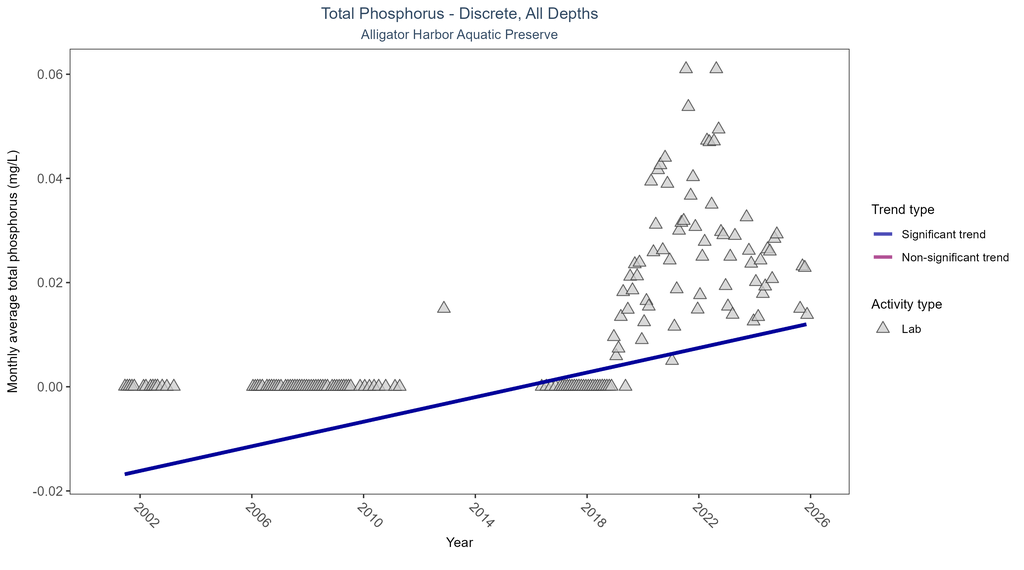

Scatter plot of monthly average total phosphorus over time. If the time series included ten or more years of discrete observations, a significant (blue) or non-significant (magenta) trend line is also shown. Only phosphorus values obtained from laboratory analyses (triangles) are included in the plot.

Table:

Monthly average total phosphorus increased by less than 0.01 mg/L per year.

| Activity Type | Statistical Trend | Sample Count | Years with Data | Period of Record | Median Result Value | Tau | Sen Intercept | Sen Slope | P |
| --- | --- | --- | --- | --- | --- | --- | --- | --- | --- |
| Lab | Increasing trend | 1157 | 20 | 2001 - 2025 | 0.00005 | 0.53779 | -0.01733 | 0.00118 | 0 |

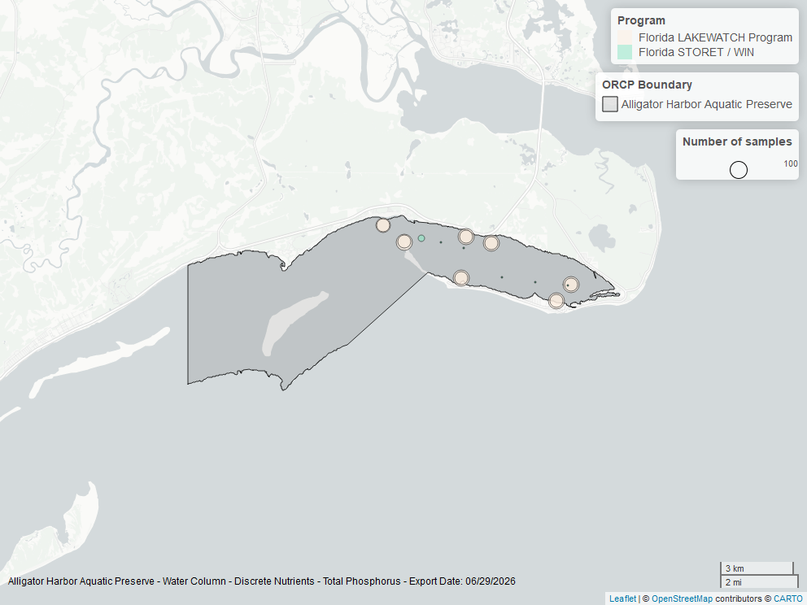

Map showing location of discrete water quality sampling locations within the boundaries of *Alligator Harbor Aquatic Preserve*. The bubble size on the maps above reflect the amount of data available at each sampling site.

## Water Quality

### Dissolved Oxygen - Continuous

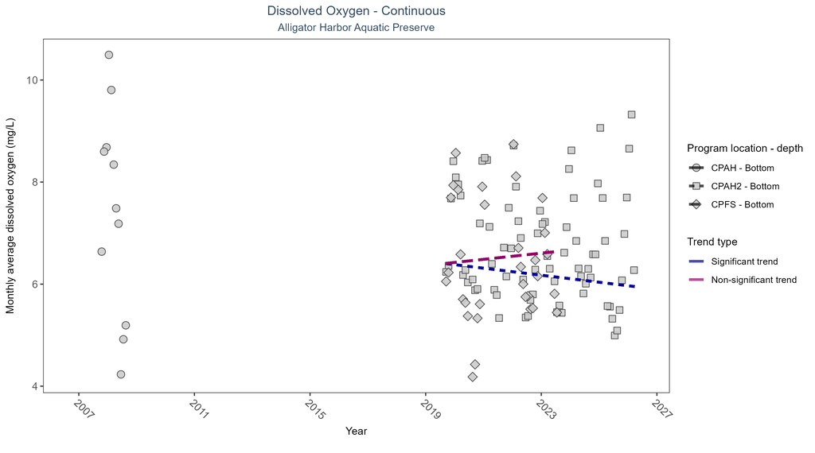

Scatter plot of monthly average dissolved oxygen over time at continuously monitored program locations. Each location is analyzed separately, with significant (blue) or non-significant (magenta) trend lines shown for time series that included five or more years of observations.

Table:

At one program location, monthly average dissolved oxygen decreased by 0.07 mg/L per year. No detectable change in monthly average dissolved oxygen was observed at one location. There was insufficient data to fit a model for one location.

| Program Location | Statistical Trend | Sample Count | Years with Data | Period of Record | Median Result Value | Tau | Sen Intercept | Sen Slope | P |
| --- | --- | --- | --- | --- | --- | --- | --- | --- | --- |
| CPAH | Insufficient data | 11557 | 2 | 2007 - 2008 | 8.0 | - | - | - | - |
| CPAH2 | Decreasing trend | 187905 | 8 | 2019 - 2026 | 6.7 | -0.22 | 6.45 | -0.07 | 0.03 |
| CPFS | No detectable trend | 56853 | 5 | 2019 - 2023 | 6.4 | 0.12 | 6.36 | 0.06 | 0.74 |

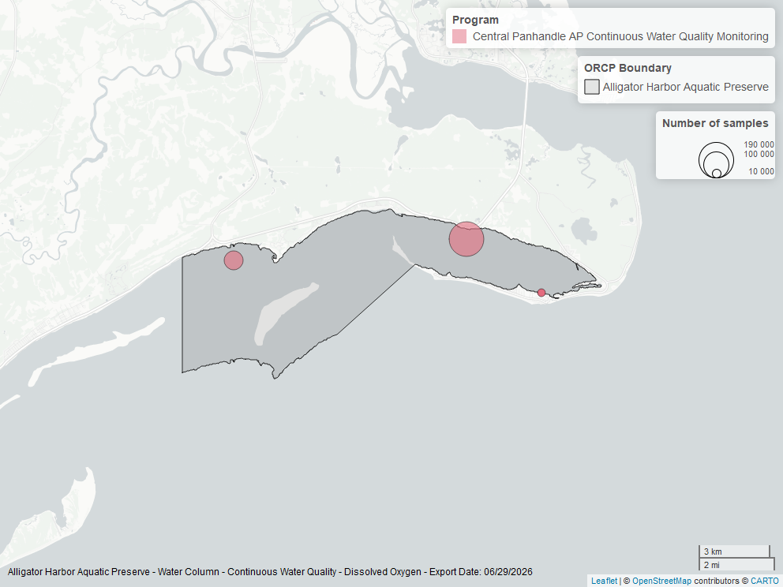

Map showing location of dissolved oxygen continuous water quality sampling locations within the boundaries of *Alligator Harbor Aquatic Preserve*. The bubble size on the maps above reflect the amount of data available at each sampling site.

### Dissolved Oxygen - Discrete

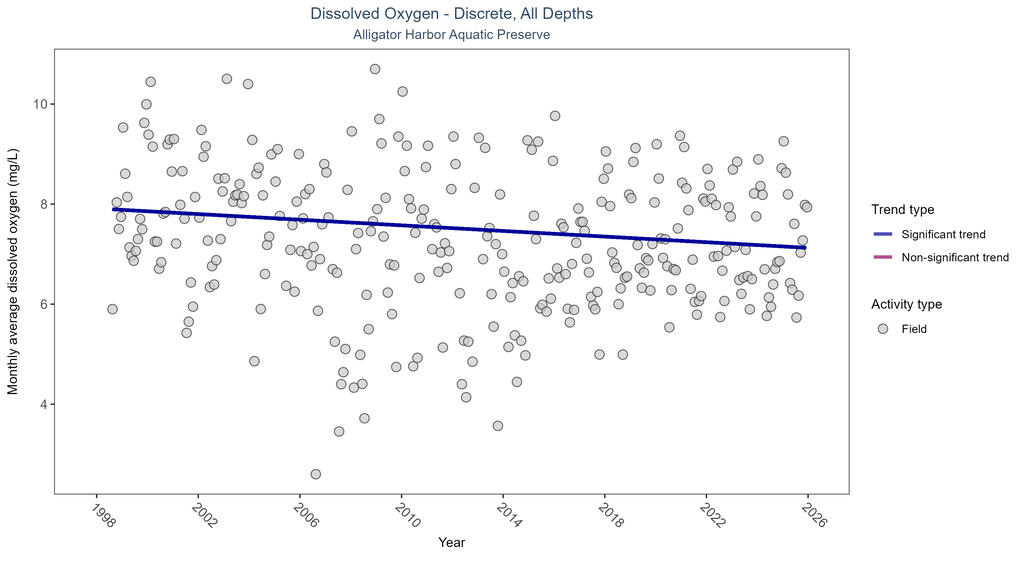

Scatter plot of monthly average dissolved oxygen over time. If the time series included ten or more years of discrete observations, a significant (blue) or non-significant (magenta) trend line is also shown. Only dissolved oxygen values measured in the field (circles) are included in the plot.

Table:

Monthly average dissolved oxygen decreased by 0.03 mg/L per year.

| Activity Type | Statistical Trend | Sample Count | Years with Data | Period of Record | Median Result Value | Tau | Sen Intercept | Sen Slope | P |
| --- | --- | --- | --- | --- | --- | --- | --- | --- | --- |
| Field | Decreasing trend | 8457 | 28 | 1998 - 2025 | 7.2 | -0.16231 | 7.91292 | -0.02812 | 0.0001 |

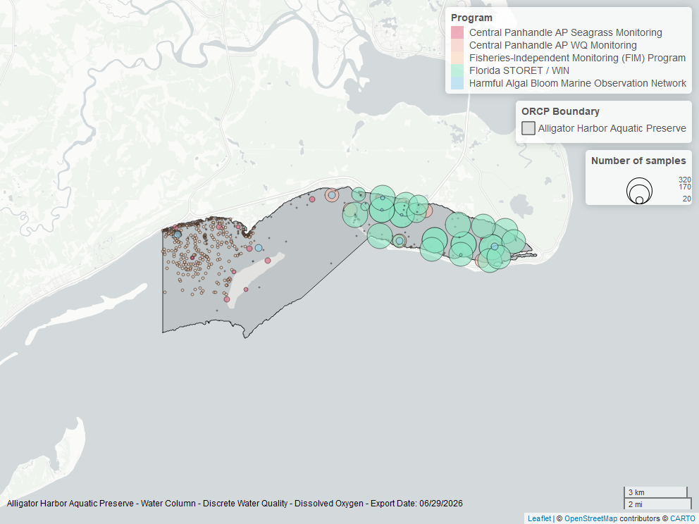

Map showing location of discrete water quality sampling locations within the boundaries of *Alligator Harbor Aquatic Preserve*. The bubble size on the maps above reflect the amount of data available at each sampling site.

### Dissolved Oxygen Saturation - Continuous

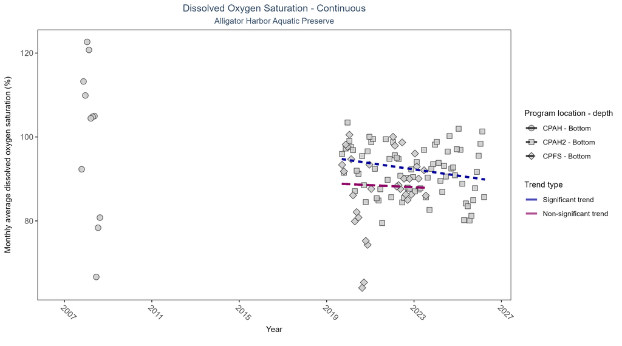

Scatter plot of monthly average dissolved oxygen saturation over time at continuously monitored program locations. Each location is analyzed separately, with significant (blue) or non-significant (magenta) trend lines shown for time series that included five or more years of observations.

Table:

At one program location, monthly average dissolved oxygen saturation decreased by 0.74% per year. No detectable change in monthly average dissolved oxygen saturation was observed at one location. There was insufficient data to fit a model for one location.

| Program Location | Statistical Trend | Sample Count | Years with Data | Period of Record | Median Result Value | Tau | Sen Intercept | Sen Slope | P |
| --- | --- | --- | --- | --- | --- | --- | --- | --- | --- |
| CPAH | Insufficient data | 11557 | 2 | 2007 - 2008 | 105.6 | - | - | - | - |
| CPAH2 | Decreasing trend | 187906 | 8 | 2019 - 2026 | 93.1 | -0.25 | 95.24 | -0.74 | 0.01 |
| CPFS | No detectable trend | 56928 | 5 | 2019 - 2023 | 90.7 | 0.02 | 89.01 | -0.24 | 1 |

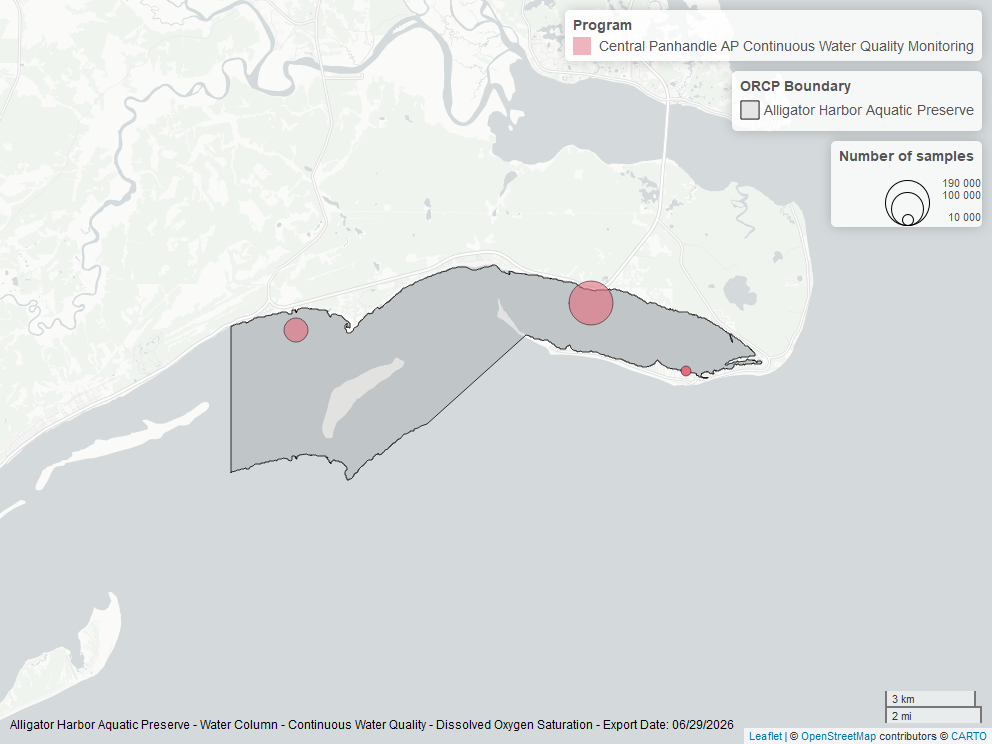

Map showing location of dissolved oxygen saturation continuous water quality sampling locations within the boundaries of *Alligator Harbor Aquatic Preserve*. The bubble size on the maps above reflect the amount of data available at each sampling site.

### Dissolved Oxygen Saturation - Discrete

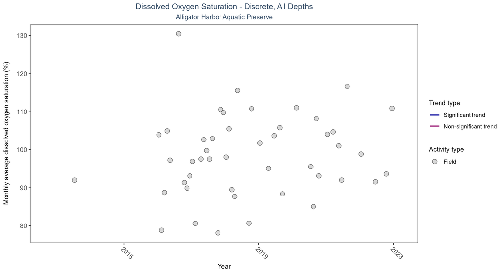

Scatter plot of monthly average dissolved oxygen saturation over time. If the time series included ten or more years of discrete observations, a significant (blue) or non-significant (magenta) trend line is also shown. Only dissolved oxygen saturation values measured in the field (circles) are included in the plot.

Table:

There was insufficient data to fit a model for dissolved oxygen saturation.

| Activity Type | Statistical Trend | Sample Count | Years with Data | Period of Record | Median Result Value | Tau | Sen Intercept | Sen Slope | P |
| --- | --- | --- | --- | --- | --- | --- | --- | --- | --- |
| Field | Insufficient data | 131 | 8 | 2013 - 2022 | 96.8 | - | - | - | - |

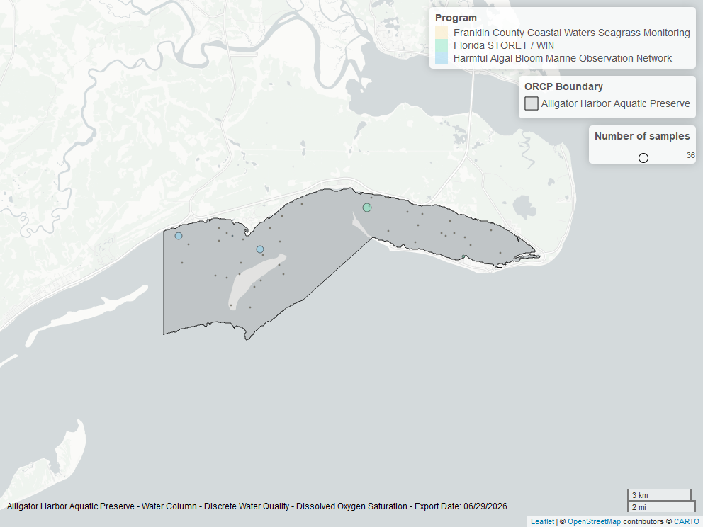

Map showing location of discrete water quality sampling locations within the boundaries of *Alligator Harbor Aquatic Preserve*. The bubble size on the maps above reflect the amount of data available at each sampling site.

### Salinity - Discrete

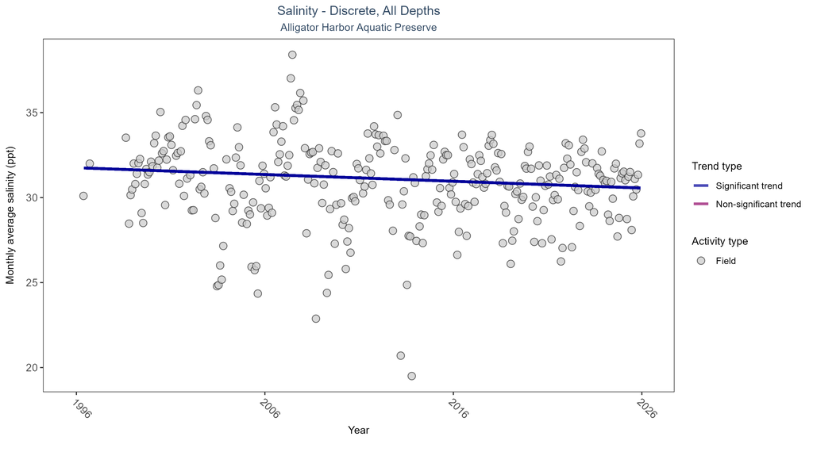

Scatter plot of monthly average salinity over time. If the time series included ten or more years of discrete observations, significant (blue) or non-significant (magenta) trend lines are also shown. Discrete salinity values derived from grab samples analyzed in the field (circles) or the laboratory (triangles) are both included in the plot.

Table:

Monthly average salinity decreased by 0.04 ppt per year.

| Activity Type | Statistical Trend | Sample Count | Years with Data | Period of Record | Median Result Value | Tau | Sen Intercept | Sen Slope | P |
| --- | --- | --- | --- | --- | --- | --- | --- | --- | --- |
| All | Decreasing trend | 9712 | 29 | 1996 - 2025 | 31.1 | -0.10895 | 31.75772 | -0.03983 | 0.0062 |

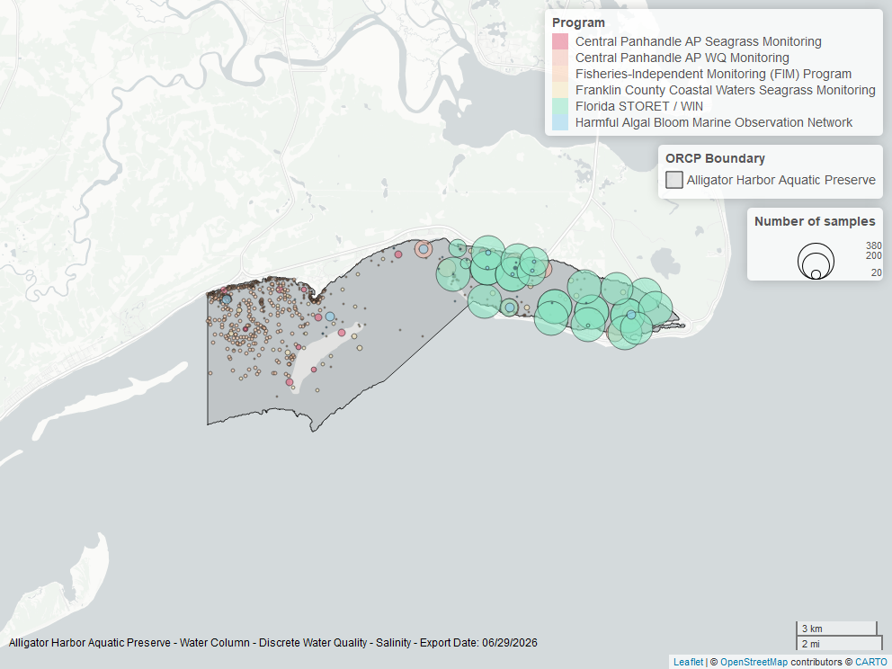

Map showing location of discrete water quality sampling locations within the boundaries of *Alligator Harbor Aquatic Preserve*. The bubble size on the maps above reflect the amount of data available at each sampling site.

### Salinity - Continuous

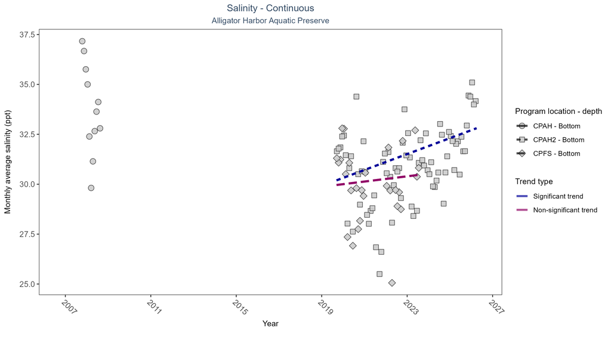

Scatter plot of monthly average salinity over time at continuously monitored program locations. Each location is analyzed separately, with significant (blue) or non-significant (magenta) trend lines shown for time series that included five or more years of observations.

Table:

At one program location, monthly average salinity increased by 0.40 ppt per year. No detectable change in monthly average salinity was observed at one location. There was insufficient data to fit a model for one location.

| Program Location | Statistical Trend | Sample Count | Years with Data | Period of Record | Median Result Value | Tau | Sen Intercept | Sen Slope | P |
| --- | --- | --- | --- | --- | --- | --- | --- | --- | --- |
| CPAH | Insufficient data | 13034 | 2 | 2007 - 2008 | 34.0 | - | - | - | - |
| CPAH2 | Increasing trend | 186148 | 8 | 2019 - 2026 | 31.2 | 0.3 | 29.92 | 0.4 | 0 |
| CPFS | No detectable trend | 60346 | 5 | 2019 - 2023 | 30.5 | 0 | 29.87 | 0.13 | 1 |

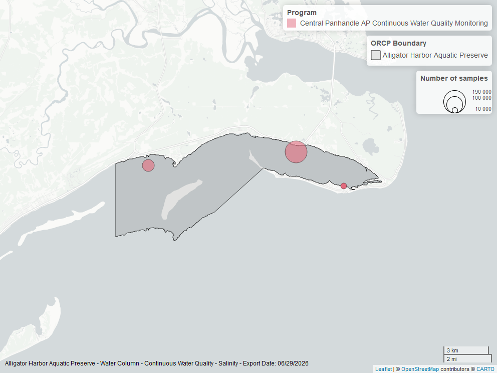

Map showing location of salinity continuous water quality sampling locations within the boundaries of *Alligator Harbor Aquatic Preserve*. The bubble size on the maps above reflect the amount of data available at each sampling site.

### Water Temperature - Continuous

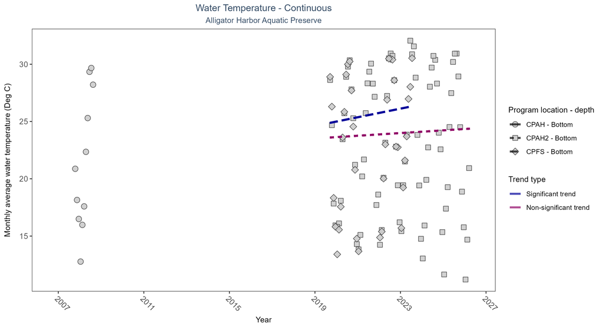

Scatter plot of monthly average water temperature over time at continuously monitored program locations. Each location is analyzed separately, with significant (blue) or non-significant (magenta) trend lines shown for time series that included five or more years of observations.

Table:

At one program location, monthly average water temperature increased by 0.38°C per year. No detectable change in monthly average water temperature was observed at one location. There was insufficient data to fit a model for one location.

| Program Location | Statistical Trend | Sample Count | Years with Data | Period of Record | Median Result Value | Tau | Sen Intercept | Sen Slope | P |
| --- | --- | --- | --- | --- | --- | --- | --- | --- | --- |
| CPAH | Insufficient data | 13034 | 2 | 2007 - 2008 | 20.9 | - | - | - | - |
| CPAH2 | No detectable trend | 204134 | 8 | 2019 - 2026 | 23.1 | 0.14 | 23.52 | 0.12 | 0.25 |
| CPFS | Increasing trend | 80801 | 5 | 2019 - 2023 | 24.1 | 0.37 | 24.62 | 0.38 | 0.03 |

[figure not shown]

Map showing location of water temperature continuous water quality sampling locations within the boundaries of *Alligator Harbor Aquatic Preserve*. The bubble size on the maps above reflect the amount of data available at each sampling site.

### Water Temperature - Discrete

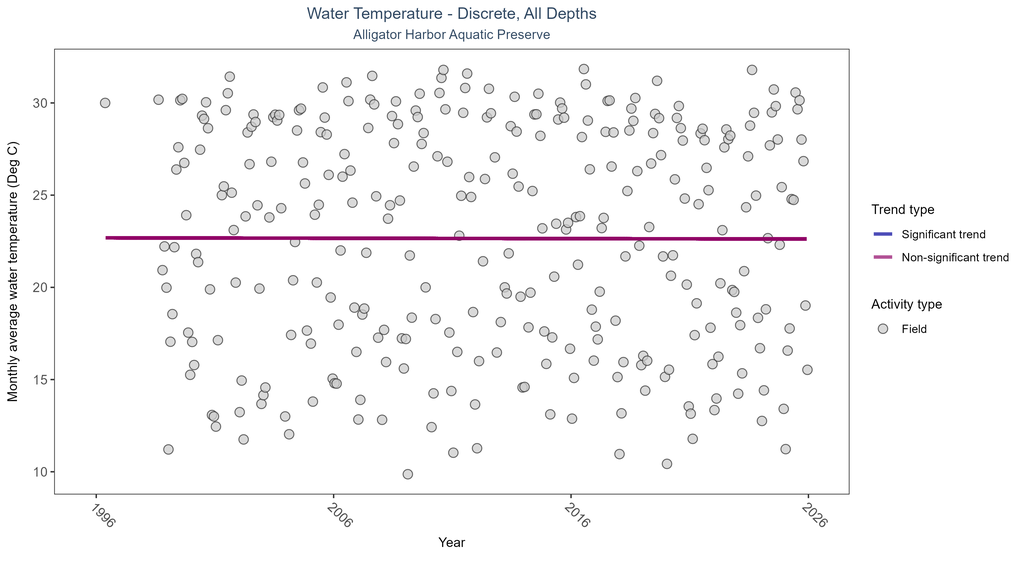

Scatter plot of monthly average water temperature over time. If the time series included ten or more years of discrete observations, a significant (blue) or non-significant (magenta) trend line is also shown. Only water temperature measurements taken in the field (circles) are included in the plot.

Table:

Water temperature showed no detectable trend between 1996 and 2025.

[output not shown]

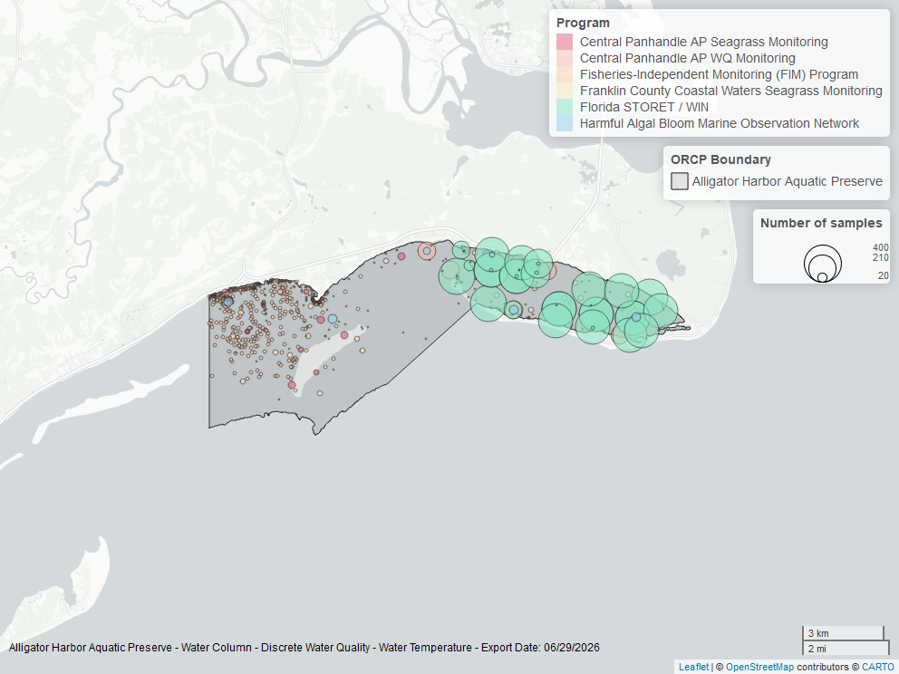

Map showing location of discrete water quality sampling locations within the boundaries of *Alligator Harbor Aquatic Preserve*. The bubble size on the maps above reflect the amount of data available at each sampling site.

### pH - Continuous

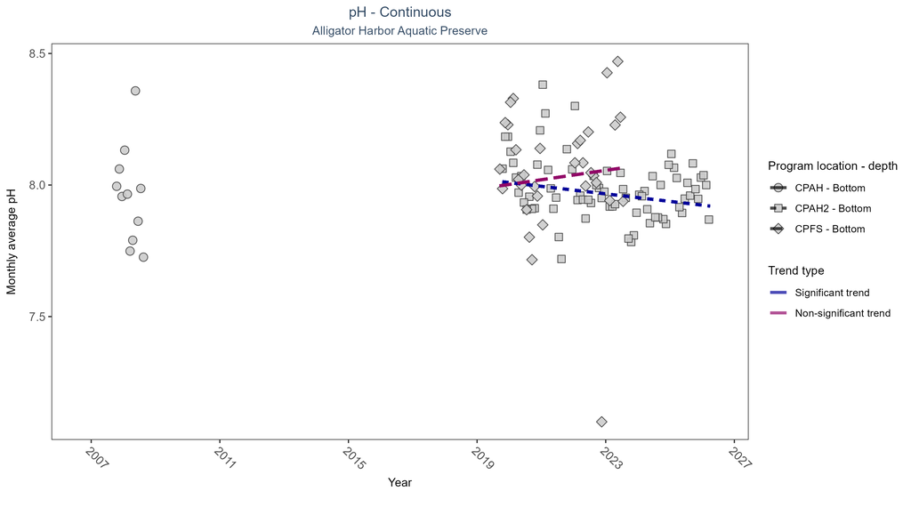

Scatter plot of monthly average pH over time at continuously monitored program locations. Each location is analyzed separately, with significant (blue) or non-significant (magenta) trend lines shown for time series that included five or more years of observations.

Table:

At one program location, monthly average pH decreased by 0.01 pH units per year. No detectable change in monthly average pH was observed at one location. There was insufficient data to fit a model for one location.

| Program Location | Statistical Trend | Sample Count | Years with Data | Period of Record | Median Result Value | Tau | Sen Intercept | Sen Slope | P |
| --- | --- | --- | --- | --- | --- | --- | --- | --- | --- |
| CPAH | Insufficient data | 13034 | 2 | 2007 - 2008 | 7.9 | - | - | - | - |
| CPAH2 | Decreasing trend | 185428 | 8 | 2019 - 2026 | 8.0 | -0.21 | 8.02 | -0.01 | 0.02 |
| CPFS | No detectable trend | 61868 | 5 | 2019 - 2023 | 8.1 | 0.19 | 7.98 | 0.02 | 0.52 |

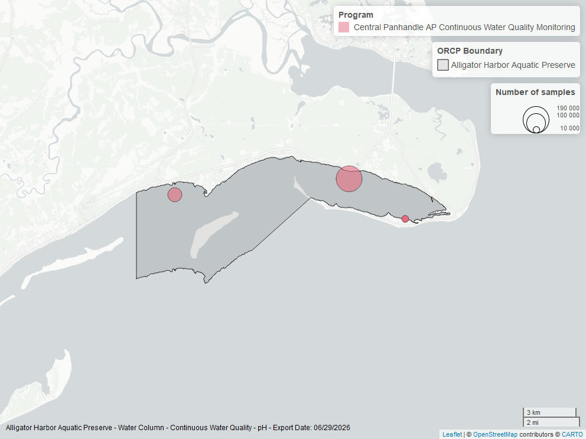

Map showing location of ph continuous water quality sampling locations within the boundaries of *Alligator Harbor Aquatic Preserve*. The bubble size on the maps above reflect the amount of data available at each sampling site.

### pH - Discrete

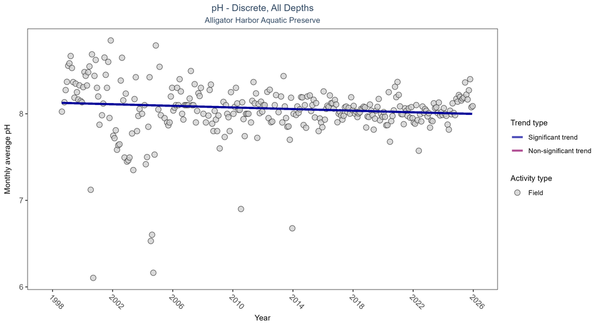

Scatter plot of monthly average pH over time. If the time series included ten or more years of discrete observations, a significant (blue) or non-significant (magenta) trend line is also shown. Only pH values measured in the field (circles) are included in the plot.

Table:

Monthly average pH decreased by less than 0.01 pH units per year.

| Activity Type | Statistical Trend | Sample Count | Years with Data | Period of Record | Median Result Value | Tau | Sen Intercept | Sen Slope | P |
| --- | --- | --- | --- | --- | --- | --- | --- | --- | --- |
| Field | Decreasing trend | 5564 | 28 | 1998 - 2025 | 8.1 | -0.11269 | 8.129 | -0.00465 | 0.0059 |

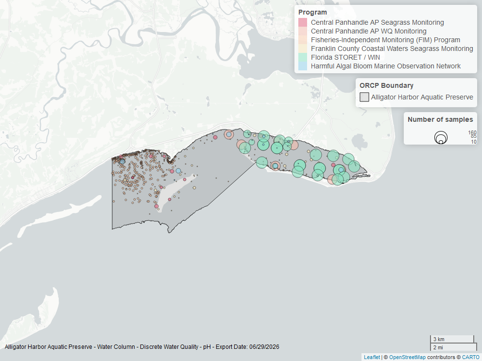

Map showing location of discrete water quality sampling locations within the boundaries of *Alligator Harbor Aquatic Preserve*. The bubble size on the maps above reflect the amount of data available at each sampling site.

### Specific Conductivity - Continuous

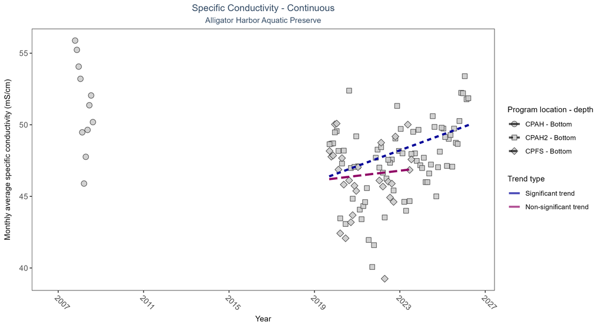

Scatter plot of monthly average specific conductivity over time at continuously monitored program locations. Each location is analyzed separately, with significant (blue) or non-significant (magenta) trend lines shown for time series that included five or more years of observations.

Table:

At one program location, monthly average specific conductivity increased by 0.55 mS/cm per year. No detectable change in monthly average specific conductivity was observed at one location. There was insufficient data to fit a model for one location.

| Program Location | Statistical Trend | Sample Count | Years with Data | Period of Record | Median Result Value | Tau | Sen Intercept | Sen Slope | P |
| --- | --- | --- | --- | --- | --- | --- | --- | --- | --- |
| CPAH | Insufficient data | 13034 | 2 | 2007 - 2008 | 51.89 | - | - | - | - |
| CPAH2 | Increasing trend | 186148 | 8 | 2019 - 2026 | 47.93 | 0.31 | 46.02 | 0.55 | 0 |
| CPFS | No detectable trend | 60346 | 5 | 2019 - 2023 | 46.91 | 0 | 46.08 | 0.18 | 1 |

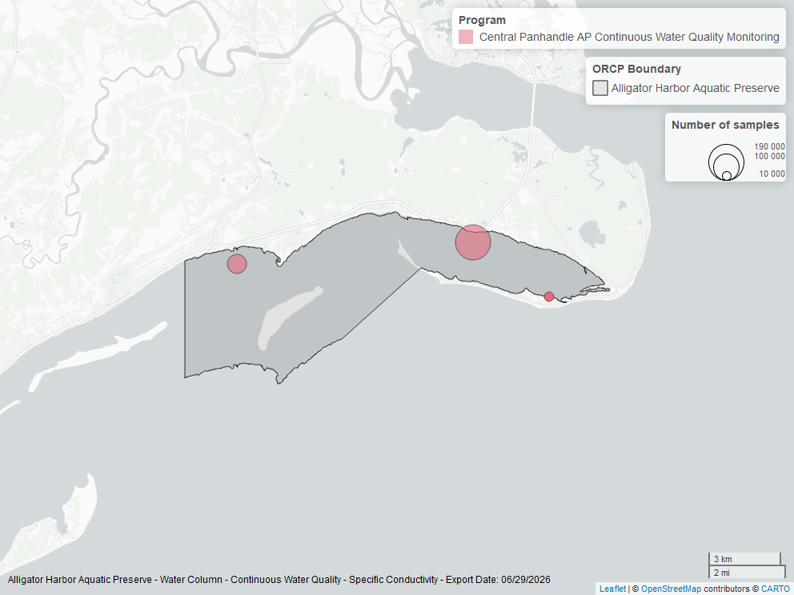

Map showing location of specific conductivity continuous water quality sampling locations within the boundaries of *Alligator Harbor Aquatic Preserve*. The bubble size on the maps above reflect the amount of data available at each sampling site.

## Water Clarity

### Turbidity - Continuous

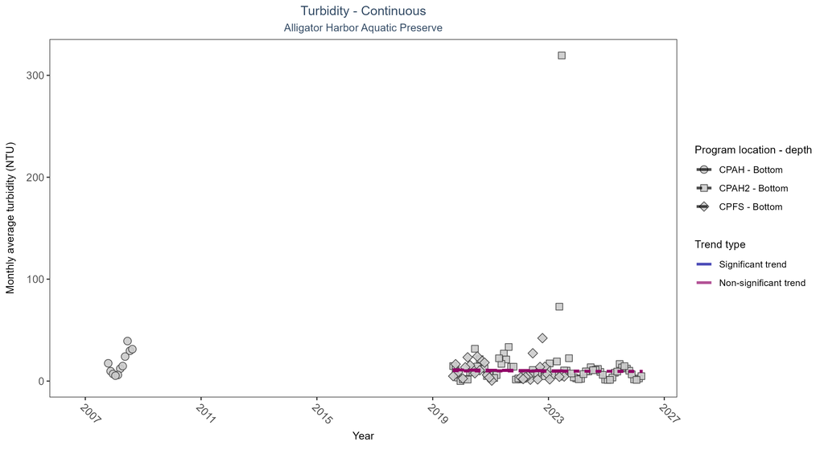

Scatter plot of monthly average turbidity over time at continuously monitored program locations. Each location is analyzed separately, with significant (blue) or non-significant (magenta) trend lines shown for time series that included five or more years of observations.

Table:

No detectable change in monthly average turbidity was observed at two locations. There was insufficient data to fit a model for one location.

| Program Location | Statistical Trend | Sample Count | Years with Data | Period of Record | Median Result Value | Tau | Sen Intercept | Sen Slope | P |
| --- | --- | --- | --- | --- | --- | --- | --- | --- | --- |
| CPAH | Insufficient data | 12558 | 2 | 2007 - 2008 | 10 | - | - | - | - |
| CPAH2 | No detectable trend | 191003 | 8 | 2019 - 2026 | 6 | -0.06 | 10.19 | -0.09 | 0.6 |
| CPFS | No detectable trend | 55980 | 5 | 2019 - 2023 | 3 | -0.16 | 11.21 | -0.26 | 1 |

[figure not shown]

Map showing location of turbidity continuous water quality sampling locations within the boundaries of *Alligator Harbor Aquatic Preserve*. The bubble size on the maps above reflect the amount of data available at each sampling site.

### Turbidity - Discrete

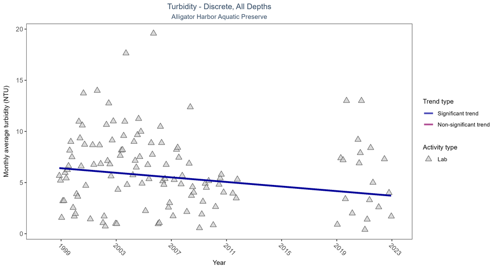

Scatter plot of monthly average turbidity over time. If the time series included ten or more years of discrete observations, a significant (blue) or non-significant (magenta) trend line is also shown. Only turbidity values measured in the laboratory (triangles) are included in the plot.

Table:

Monthly average turbidity decreased by 0.11 NTU per year, indicating an increase in water clarity.

| Activity Type | Statistical Trend | Sample Count | Years with Data | Period of Record | Median Result Value | Tau | Sen Intercept | Sen Slope | P |
| --- | --- | --- | --- | --- | --- | --- | --- | --- | --- |
| Lab | Decreasing trend | 3543 | 18 | 1998 - 2022 | 5.3 | -0.24321 | 6.51312 | -0.11185 | 0.0012 |

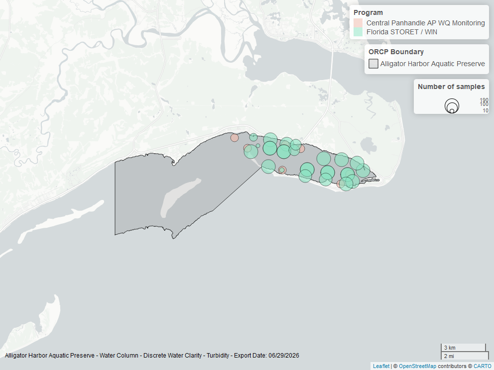

Map showing location of discrete water quality sampling locations within the boundaries of *Alligator Harbor Aquatic Preserve*. The bubble size on the maps above reflect the amount of data available at each sampling site.

### Total Suspended Solids - Discrete

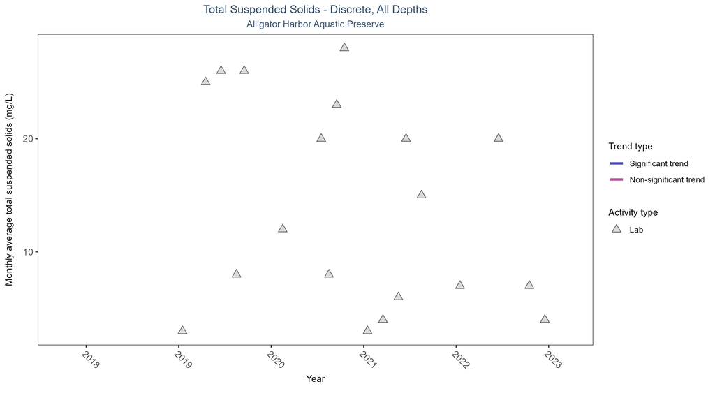

Scatter plot of monthly average total suspended solids (TSS) over time. If the time series included ten or more years of discrete observations, a significant (blue) or non-significant (magenta) trend line is also shown. Only TSS values obtained from laboratory analyses (triangles) are included in the plot.

Table:

There was insufficient data to fit a model for total suspended solids.

| Activity Type | Statistical Trend | Sample Count | Years with Data | Period of Record | Median Result Value | Tau | Sen Intercept | Sen Slope | P |
| --- | --- | --- | --- | --- | --- | --- | --- | --- | --- |
| Lab | Insufficient data | 19 | 4 | 2019 - 2022 | 12 | - | - | - | - |

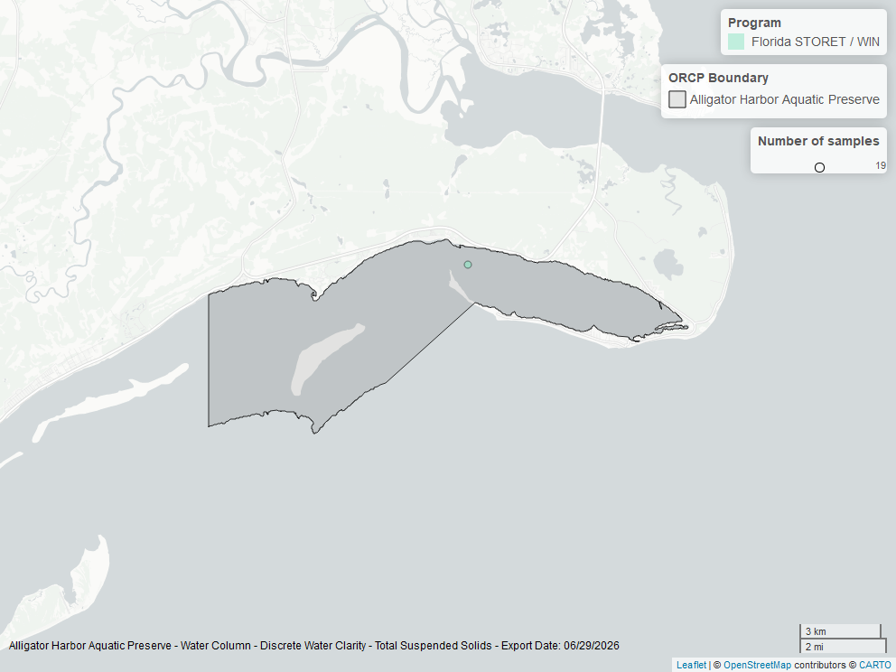

Map showing location of discrete water quality sampling locations within the boundaries of *Alligator Harbor Aquatic Preserve*. The bubble size on the maps above reflect the amount of data available at each sampling site.